# Risk Factor Analysis

## Outcome Variable

**Outcome Variable:** whz

## Predictor Variables

**Intervention Variable:** birthlen

**Adjustment Set:**

- arm
- sex
- W_mage
- meducyrs
- feducyrs
- vagbrth
- single
- brthmon
- W_parity
- delta_W_mage
- delta_meducyrs
- delta_feducyrs
- delta_vagbrth
- delta_single
- delta_brthmon
- delta_W_parity

## Stratifying Variables

The analysis was stratified on these variable(s):

- agecat
- studyid
- country

## Data Summary

| agecat | studyid | country | birthlen | n_cell | n | outcome_variable |
| --- | --- | --- | --- | --- | --- | --- |
| Birth | CMC-V-BCS-2002 | INDIA | >=50 cm | 13 | 86 | whz |
| Birth | CMC-V-BCS-2002 | INDIA | <48 cm | 33 | 86 | whz |
| Birth | CMC-V-BCS-2002 | INDIA | [48-50) cm | 40 | 86 | whz |
| Birth | CMIN | BANGLADESH | >=50 cm | 2 | 19 | whz |
| Birth | CMIN | BANGLADESH | <48 cm | 9 | 19 | whz |
| Birth | CMIN | BANGLADESH | [48-50) cm | 8 | 19 | whz |
| Birth | COHORTS | GUATEMALA | >=50 cm | 396 | 756 | whz |
| Birth | COHORTS | GUATEMALA | <48 cm | 132 | 756 | whz |
| Birth | COHORTS | GUATEMALA | [48-50) cm | 228 | 756 | whz |
| Birth | COHORTS | INDIA | >=50 cm | 1404 | 6193 | whz |
| Birth | COHORTS | INDIA | <48 cm | 2354 | 6193 | whz |
| Birth | COHORTS | INDIA | [48-50) cm | 2435 | 6193 | whz |
| Birth | COHORTS | PHILIPPINES | >=50 cm | 1110 | 2899 | whz |
| Birth | COHORTS | PHILIPPINES | <48 cm | 651 | 2899 | whz |
| Birth | COHORTS | PHILIPPINES | [48-50) cm | 1138 | 2899 | whz |
| Birth | CONTENT | PERU | >=50 cm | 1 | 2 | whz |
| Birth | CONTENT | PERU | <48 cm | 1 | 2 | whz |
| Birth | CONTENT | PERU | [48-50) cm | 0 | 2 | whz |
| Birth | EE | PAKISTAN | >=50 cm | 21 | 177 | whz |
| Birth | EE | PAKISTAN | <48 cm | 102 | 177 | whz |
| Birth | EE | PAKISTAN | [48-50) cm | 54 | 177 | whz |
| Birth | GMS-Nepal | NEPAL | >=50 cm | 114 | 641 | whz |
| Birth | GMS-Nepal | NEPAL | <48 cm | 319 | 641 | whz |
| Birth | GMS-Nepal | NEPAL | [48-50) cm | 208 | 641 | whz |
| Birth | IRC | INDIA | >=50 cm | 120 | 343 | whz |
| Birth | IRC | INDIA | <48 cm | 87 | 343 | whz |
| Birth | IRC | INDIA | [48-50) cm | 136 | 343 | whz |
| Birth | JiVitA-3 | BANGLADESH | >=50 cm | 1243 | 18014 | whz |
| Birth | JiVitA-3 | BANGLADESH | <48 cm | 11692 | 18014 | whz |
| Birth | JiVitA-3 | BANGLADESH | [48-50) cm | 5079 | 18014 | whz |

[output cut: 198 more lines]

The following strata were considered:

- agecat: 24 months, studyid: CMC-V-BCS-2002, country: INDIA
- agecat: 24 months, studyid: CMIN, country: BANGLADESH
- agecat: 24 months, studyid: COHORTS, country: GUATEMALA
- agecat: 24 months, studyid: COHORTS, country: INDIA
- agecat: 24 months, studyid: COHORTS, country: PHILIPPINES
- agecat: 24 months, studyid: CONTENT, country: PERU
- agecat: 24 months, studyid: EE, country: PAKISTAN
- agecat: 24 months, studyid: GMS-Nepal, country: NEPAL
- agecat: 24 months, studyid: IRC, country: INDIA
- agecat: 24 months, studyid: JiVitA-3, country: BANGLADESH
- agecat: 24 months, studyid: JiVitA-4, country: BANGLADESH
- agecat: 24 months, studyid: Keneba, country: GAMBIA
- agecat: 24 months, studyid: MAL-ED, country: BANGLADESH
- agecat: 24 months, studyid: MAL-ED, country: BRAZIL
- agecat: 24 months, studyid: MAL-ED, country: INDIA
- agecat: 24 months, studyid: MAL-ED, country: NEPAL
- agecat: 24 months, studyid: MAL-ED, country: PERU
- agecat: 24 months, studyid: MAL-ED, country: SOUTH AFRICA
- agecat: 24 months, studyid: MAL-ED, country: TANZANIA, UNITED REPUBLIC OF
- agecat: 24 months, studyid: NIH-Birth, country: BANGLADESH
- agecat: 24 months, studyid: NIH-Crypto, country: BANGLADESH
- agecat: 24 months, studyid: PROBIT, country: BELARUS
- agecat: 24 months, studyid: PROVIDE, country: BANGLADESH
- agecat: 24 months, studyid: ZVITAMBO, country: ZIMBABWE
- agecat: 6 months, studyid: CMC-V-BCS-2002, country: INDIA
- agecat: 6 months, studyid: CMIN, country: BANGLADESH
- agecat: 6 months, studyid: COHORTS, country: GUATEMALA
- agecat: 6 months, studyid: COHORTS, country: INDIA
- agecat: 6 months, studyid: COHORTS, country: PHILIPPINES
- agecat: 6 months, studyid: CONTENT, country: PERU
- agecat: 6 months, studyid: EE, country: PAKISTAN
- agecat: 6 months, studyid: GMS-Nepal, country: NEPAL
- agecat: 6 months, studyid: IRC, country: INDIA
- agecat: 6 months, studyid: JiVitA-3, country: BANGLADESH
- agecat: 6 months, studyid: JiVitA-4, country: BANGLADESH
- agecat: 6 months, studyid: Keneba, country: GAMBIA
- agecat: 6 months, studyid: MAL-ED, country: BANGLADESH
- agecat: 6 months, studyid: MAL-ED, country: BRAZIL
- agecat: 6 months, studyid: MAL-ED, country: INDIA
- agecat: 6 months, studyid: MAL-ED, country: NEPAL
- agecat: 6 months, studyid: MAL-ED, country: PERU
- agecat: 6 months, studyid: MAL-ED, country: SOUTH AFRICA
- agecat: 6 months, studyid: MAL-ED, country: TANZANIA, UNITED REPUBLIC OF
- agecat: 6 months, studyid: NIH-Birth, country: BANGLADESH
- agecat: 6 months, studyid: NIH-Crypto, country: BANGLADESH
- agecat: 6 months, studyid: PROBIT, country: BELARUS
- agecat: 6 months, studyid: PROVIDE, country: BANGLADESH
- agecat: 6 months, studyid: ResPak, country: PAKISTAN
- agecat: 6 months, studyid: SAS-CompFeed, country: INDIA
- agecat: 6 months, studyid: ZVITAMBO, country: ZIMBABWE
- agecat: Birth, studyid: CMC-V-BCS-2002, country: INDIA
- agecat: Birth, studyid: CMIN, country: BANGLADESH
- agecat: Birth, studyid: COHORTS, country: GUATEMALA
- agecat: Birth, studyid: COHORTS, country: INDIA
- agecat: Birth, studyid: COHORTS, country: PHILIPPINES
- agecat: Birth, studyid: CONTENT, country: PERU
- agecat: Birth, studyid: EE, country: PAKISTAN
- agecat: Birth, studyid: GMS-Nepal, country: NEPAL
- agecat: Birth, studyid: IRC, country: INDIA
- agecat: Birth, studyid: JiVitA-3, country: BANGLADESH
- agecat: Birth, studyid: JiVitA-4, country: BANGLADESH
- agecat: Birth, studyid: Keneba, country: GAMBIA
- agecat: Birth, studyid: MAL-ED, country: BANGLADESH
- agecat: Birth, studyid: MAL-ED, country: BRAZIL
- agecat: Birth, studyid: MAL-ED, country: INDIA
- agecat: Birth, studyid: MAL-ED, country: NEPAL
- agecat: Birth, studyid: MAL-ED, country: PERU
- agecat: Birth, studyid: MAL-ED, country: SOUTH AFRICA
- agecat: Birth, studyid: MAL-ED, country: TANZANIA, UNITED REPUBLIC OF
- agecat: Birth, studyid: NIH-Birth, country: BANGLADESH
- agecat: Birth, studyid: NIH-Crypto, country: BANGLADESH
- agecat: Birth, studyid: PROBIT, country: BELARUS
- agecat: Birth, studyid: PROVIDE, country: BANGLADESH
- agecat: Birth, studyid: ResPak, country: PAKISTAN
- agecat: Birth, studyid: SAS-CompFeed, country: INDIA
- agecat: Birth, studyid: ZVITAMBO, country: ZIMBABWE

### Dropped Strata

Some strata were dropped due to rare outcomes:

- agecat: Birth, studyid: CMIN, country: BANGLADESH
- agecat: Birth, studyid: CONTENT, country: PERU
- agecat: 6 months, studyid: CMIN, country: BANGLADESH
- agecat: 6 months, studyid: CONTENT, country: PERU
- agecat: 24 months, studyid: CMIN, country: BANGLADESH
- agecat: 24 months, studyid: CONTENT, country: PERU

## Methods Detail

We’re interested in the causal parameters $E[Y_a]$ for all values of $a \in \mathcal{A}$. These parameters represent the mean outcome if, possibly contrary to fact, we intervened to set all units to have $A=a$. Under the randomization and positivity assumptions, these are identified by the statistical parameters $\psi_a=E_W[E_{Y|A,W}(Y|A=a,W)]$. In addition, we’re interested in the mean of $Y$, $E[Y]$ under no intervention (the observed mean). We will estimate these parameters by using SuperLearner to fit the relevant likelihood factors – $E_{Y|A,W}(Y|A=a,W)$ and $p(A=a|W)$, and then updating our likelihood fit using a joint TMLE.

For unadjusted analyses ($W=\{\}$), initial likelihoods were estimated using Lrnr_glm to estimate the simple $E(Y|A)$ and Lrnr_mean to estimate $p(A)$. For adjusted analyses, a small library containing Lrnr_glmnet, Lrnr_xgboost, and Lrnr_mean was used.

Having estimated these parameters, we will then use the delta method to estimate relative risks and attributable risks relative to a prespecified baseline level of $A$.

# Results Detail

## Results Plots

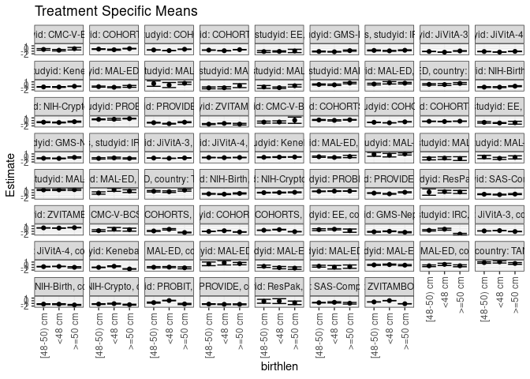

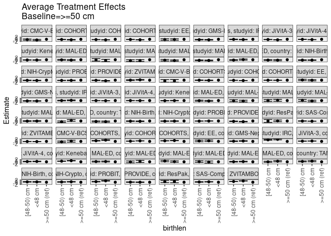

[figure not shown]

## Results Table

### Parameter: TSM

| agecat | studyid | country | intervention_level | baseline_level | estimate | ci_lower | ci_upper |
| --- | --- | --- | --- | --- | --- | --- | --- |
| Birth | CMC-V-BCS-2002 | INDIA | >=50 cm | NA | -0.3751395 | -0.9341395 | 0.1838605 |
| Birth | CMC-V-BCS-2002 | INDIA | <48 cm | NA | -0.2055880 | -0.8312060 | 0.4200300 |
| Birth | CMC-V-BCS-2002 | INDIA | [48-50) cm | NA | -0.7462172 | -1.0866617 | -0.4057727 |
| Birth | COHORTS | GUATEMALA | >=50 cm | NA | -1.4466500 | -1.5722875 | -1.3210125 |
| Birth | COHORTS | GUATEMALA | <48 cm | NA | -0.2412103 | -0.5062741 | 0.0238534 |
| Birth | COHORTS | GUATEMALA | [48-50) cm | NA | -0.8606734 | -1.0375351 | -0.6838117 |
| Birth | COHORTS | INDIA | >=50 cm | NA | -1.2409749 | -1.2999553 | -1.1819945 |
| Birth | COHORTS | INDIA | <48 cm | NA | -0.7682179 | -0.8185574 | -0.7178783 |
| Birth | COHORTS | INDIA | [48-50) cm | NA | -1.0450158 | -1.0914926 | -0.9985391 |
| Birth | COHORTS | PHILIPPINES | >=50 cm | NA | -1.1228433 | -1.1935779 | -1.0521087 |
| Birth | COHORTS | PHILIPPINES | <48 cm | NA | -0.3544620 | -0.4591605 | -0.2497635 |
| Birth | COHORTS | PHILIPPINES | [48-50) cm | NA | -0.5877119 | -0.6565567 | -0.5188672 |
| Birth | EE | PAKISTAN | >=50 cm | NA | -0.7481851 | -1.3636115 | -0.1327587 |
| Birth | EE | PAKISTAN | <48 cm | NA | -0.2031183 | -0.4461626 | 0.0399261 |
| Birth | EE | PAKISTAN | [48-50) cm | NA | -0.3666740 | -0.7172798 | -0.0160682 |
| Birth | GMS-Nepal | NEPAL | >=50 cm | NA | -1.3557840 | -1.5524914 | -1.1590767 |
| Birth | GMS-Nepal | NEPAL | <48 cm | NA | -0.9877442 | -1.1192221 | -0.8562662 |
| Birth | GMS-Nepal | NEPAL | [48-50) cm | NA | -1.1793415 | -1.3194635 | -1.0392195 |
| Birth | IRC | INDIA | >=50 cm | NA | -2.0555440 | -2.3451329 | -1.7659552 |
| Birth | IRC | INDIA | <48 cm | NA | -0.1919930 | -0.5505909 | 0.1666050 |
| Birth | IRC | INDIA | [48-50) cm | NA | -0.6125069 | -0.8630797 | -0.3619342 |
| Birth | JiVitA-3 | BANGLADESH | >=50 cm | NA | -1.0790841 | -1.1370386 | -1.0211296 |
| Birth | JiVitA-3 | BANGLADESH | <48 cm | NA | -0.7221917 | -0.7446944 | -0.6996889 |
| Birth | JiVitA-3 | BANGLADESH | [48-50) cm | NA | -0.8451643 | -0.8782527 | -0.8120758 |
| Birth | JiVitA-4 | BANGLADESH | >=50 cm | NA | -0.9739452 | -1.2191795 | -0.7287109 |
| Birth | JiVitA-4 | BANGLADESH | <48 cm | NA | -0.6384027 | -0.7039339 | -0.5728716 |
| Birth | JiVitA-4 | BANGLADESH | [48-50) cm | NA | -0.7277627 | -0.8242413 | -0.6312840 |
| Birth | Keneba | GAMBIA | >=50 cm | NA | -1.5900856 | -1.6723969 | -1.5077742 |
| Birth | Keneba | GAMBIA | <48 cm | NA | -0.5887046 | -0.7499832 | -0.4274261 |
| Birth | Keneba | GAMBIA | [48-50) cm | NA | -1.0076804 | -1.1071019 | -0.9082589 |

[output cut: 180 more lines]

### Parameter: E(Y)

| agecat | studyid | country | intervention_level | baseline_level | estimate | ci_lower | ci_upper |
| --- | --- | --- | --- | --- | --- | --- | --- |
| Birth | CMC-V-BCS-2002 | INDIA | NA | NA | -0.4648256 | -0.7643210 | -0.1653302 |
| Birth | COHORTS | GUATEMALA | NA | NA | -1.0621429 | -1.1631387 | -0.9611471 |
| Birth | COHORTS | INDIA | NA | NA | -0.9847457 | -1.0145305 | -0.9549609 |
| Birth | COHORTS | PHILIPPINES | NA | NA | -0.7427251 | -0.7890855 | -0.6963647 |
| Birth | EE | PAKISTAN | NA | NA | -0.3333051 | -0.5209779 | -0.1456323 |
| Birth | GMS-Nepal | NEPAL | NA | NA | -1.1164431 | -1.2040134 | -1.0288728 |
| Birth | IRC | INDIA | NA | NA | -1.0105831 | -1.1973019 | -0.8238643 |
| Birth | JiVitA-3 | BANGLADESH | NA | NA | -0.7778272 | -0.7968313 | -0.7588232 |
| Birth | JiVitA-4 | BANGLADESH | NA | NA | -0.6886269 | -0.7410452 | -0.6362086 |
| Birth | Keneba | GAMBIA | NA | NA | -1.2343618 | -1.2966897 | -1.1720339 |
| Birth | MAL-ED | BANGLADESH | NA | NA | -0.9418605 | -1.0869834 | -0.7967375 |
| Birth | MAL-ED | BRAZIL | NA | NA | 0.4029032 | 0.0896793 | 0.7161272 |
| Birth | MAL-ED | INDIA | NA | NA | -0.9324444 | -1.2067907 | -0.6580982 |
| Birth | MAL-ED | NEPAL | NA | NA | -0.7684615 | -1.1257770 | -0.4111460 |
| Birth | MAL-ED | PERU | NA | NA | -0.0520175 | -0.1725298 | 0.0684947 |
| Birth | MAL-ED | SOUTH AFRICA | NA | NA | -0.1925833 | -0.4053570 | 0.0201904 |
| Birth | MAL-ED | TANZANIA, UNITED REPUBLIC OF | NA | NA | 0.7624348 | 0.5710709 | 0.9537986 |
| Birth | NIH-Birth | BANGLADESH | NA | NA | -1.3499217 | -1.4444634 | -1.2553801 |
| Birth | NIH-Crypto | BANGLADESH | NA | NA | -1.2441513 | -1.3281130 | -1.1601897 |
| Birth | PROBIT | BELARUS | NA | NA | -1.1491782 | -1.3593933 | -0.9389630 |
| Birth | PROVIDE | BANGLADESH | NA | NA | -1.2984586 | -1.3752758 | -1.2216415 |
| Birth | ResPak | PAKISTAN | NA | NA | -0.3663158 | -0.7677415 | 0.0351099 |
| Birth | SAS-CompFeed | INDIA | NA | NA | -0.6700453 | -0.8474950 | -0.4925957 |
| Birth | ZVITAMBO | ZIMBABWE | NA | NA | -0.5154897 | -0.5413479 | -0.4896314 |
| 6 months | CMC-V-BCS-2002 | INDIA | NA | NA | -0.4931429 | -0.7890257 | -0.1972601 |
| 6 months | COHORTS | GUATEMALA | NA | NA | 0.2193904 | 0.1338361 | 0.3049448 |
| 6 months | COHORTS | INDIA | NA | NA | -0.6983940 | -0.7275858 | -0.6692022 |
| 6 months | COHORTS | PHILIPPINES | NA | NA | -0.2943461 | -0.3357404 | -0.2529517 |
| 6 months | EE | PAKISTAN | NA | NA | -0.8527871 | -0.9897809 | -0.7157933 |
| 6 months | GMS-Nepal | NEPAL | NA | NA | -0.6026850 | -0.6889114 | -0.5164586 |
| 6 months | IRC | INDIA | NA | NA | -0.6409340 | -0.7788045 | -0.5030635 |
| 6 months | JiVitA-3 | BANGLADESH | NA | NA | -0.6072473 | -0.6281750 | -0.5863195 |
| 6 months | JiVitA-4 | BANGLADESH | NA | NA | -0.3757033 | -0.4185197 | -0.3328869 |
| 6 months | Keneba | GAMBIA | NA | NA | -0.1974657 | -0.2592285 | -0.1357029 |
| 6 months | MAL-ED | BANGLADESH | NA | NA | -0.1458294 | -0.2842227 | -0.0074361 |
| 6 months | MAL-ED | BRAZIL | NA | NA | 0.8580508 | 0.5394364 | 1.1766653 |
| 6 months | MAL-ED | INDIA | NA | NA | -0.6644715 | -0.9812646 | -0.3476785 |
| 6 months | MAL-ED | NEPAL | NA | NA | -0.4072436 | -0.7125541 | -0.1019331 |
| 6 months | MAL-ED | PERU | NA | NA | 1.0510698 | 0.9102569 | 1.1918826 |
| 6 months | MAL-ED | SOUTH AFRICA | NA | NA | 0.4017921 | 0.1396820 | 0.6639023 |
| 6 months | MAL-ED | TANZANIA, UNITED REPUBLIC OF | NA | NA | 0.5110593 | 0.3321196 | 0.6899991 |
| 6 months | NIH-Birth | BANGLADESH | NA | NA | -0.4636760 | -0.5549942 | -0.3723578 |
| 6 months | NIH-Crypto | BANGLADESH | NA | NA | 0.0297622 | -0.0491685 | 0.1086930 |
| 6 months | PROBIT | BELARUS | NA | NA | 0.5741099 | 0.5141290 | 0.6340908 |
| 6 months | PROVIDE | BANGLADESH | NA | NA | -0.1990907 | -0.2817968 | -0.1163845 |
| 6 months | ResPak | PAKISTAN | NA | NA | 0.2176471 | -0.1948962 | 0.6301903 |
| 6 months | SAS-CompFeed | INDIA | NA | NA | -0.6674924 | -0.8047012 | -0.5302836 |
| 6 months | ZVITAMBO | ZIMBABWE | NA | NA | 0.3089671 | 0.2831612 | 0.3347730 |
| 24 months | CMC-V-BCS-2002 | INDIA | NA | NA | -0.4529088 | -0.6339053 | -0.2719123 |
| 24 months | COHORTS | GUATEMALA | NA | NA | -0.2016312 | -0.2740358 | -0.1292266 |
| 24 months | COHORTS | INDIA | NA | NA | -0.5945743 | -0.6244188 | -0.5647299 |
| 24 months | COHORTS | PHILIPPINES | NA | NA | -0.6103189 | -0.6471371 | -0.5735006 |
| 24 months | EE | PAKISTAN | NA | NA | -0.9929439 | -1.1707082 | -0.8151796 |
| 24 months | GMS-Nepal | NEPAL | NA | NA | -1.1336900 | -1.2226955 | -1.0446844 |
| 24 months | IRC | INDIA | NA | NA | -0.7536624 | -0.8467166 | -0.6606082 |
| 24 months | JiVitA-3 | BANGLADESH | NA | NA | -1.3046571 | -1.3299587 | -1.2793555 |
| 24 months | JiVitA-4 | BANGLADESH | NA | NA | -1.2411122 | -1.2752162 | -1.2070083 |
| 24 months | Keneba | GAMBIA | NA | NA | -0.7949018 | -0.8551887 | -0.7346150 |
| 24 months | MAL-ED | BANGLADESH | NA | NA | -0.8296257 | -0.9583167 | -0.7009347 |
| 24 months | MAL-ED | BRAZIL | NA | NA | 0.2347222 | -0.1702799 | 0.6397243 |
| 24 months | MAL-ED | INDIA | NA | NA | -1.1144872 | -1.3842438 | -0.8447305 |
| 24 months | MAL-ED | NEPAL | NA | NA | -0.8921154 | -1.1547051 | -0.6295257 |
| 24 months | MAL-ED | PERU | NA | NA | 0.0490417 | -0.0909855 | 0.1890689 |
| 24 months | MAL-ED | SOUTH AFRICA | NA | NA | 0.3919414 | 0.2031981 | 0.5806847 |
| 24 months | MAL-ED | TANZANIA, UNITED REPUBLIC OF | NA | NA | 0.1324519 | -0.0568428 | 0.3217466 |
| 24 months | NIH-Birth | BANGLADESH | NA | NA | -0.9069451 | -1.0069853 | -0.8069049 |
| 24 months | NIH-Crypto | BANGLADESH | NA | NA | -0.6103502 | -0.7050157 | -0.5156847 |
| 24 months | PROBIT | BELARUS | NA | NA | 0.6981406 | 0.5843775 | 0.8119038 |
| 24 months | PROVIDE | BANGLADESH | NA | NA | -0.8928670 | -0.9755153 | -0.8102187 |
| 24 months | ZVITAMBO | ZIMBABWE | NA | NA | -1.1803052 | -1.2806626 | -1.0799477 |

### Parameter: ATE

| agecat | studyid | country | intervention_level | baseline_level | estimate | ci_lower | ci_upper |
| --- | --- | --- | --- | --- | --- | --- | --- |
| Birth | CMC-V-BCS-2002 | INDIA | >=50 cm | >=50 cm | 0.0000000 | 0.0000000 | 0.0000000 |
| Birth | CMC-V-BCS-2002 | INDIA | <48 cm | >=50 cm | 0.1695515 | -0.6708764 | 1.0099793 |
| Birth | CMC-V-BCS-2002 | INDIA | [48-50) cm | >=50 cm | -0.3710777 | -1.0263634 | 0.2842080 |
| Birth | COHORTS | GUATEMALA | >=50 cm | >=50 cm | 0.0000000 | 0.0000000 | 0.0000000 |
| Birth | COHORTS | GUATEMALA | <48 cm | >=50 cm | 1.2054397 | 0.9124856 | 1.4983937 |
| Birth | COHORTS | GUATEMALA | [48-50) cm | >=50 cm | 0.5859766 | 0.3692178 | 0.8027354 |
| Birth | COHORTS | INDIA | >=50 cm | >=50 cm | 0.0000000 | 0.0000000 | 0.0000000 |
| Birth | COHORTS | INDIA | <48 cm | >=50 cm | 0.4727570 | 0.3953442 | 0.5501698 |
| Birth | COHORTS | INDIA | [48-50) cm | >=50 cm | 0.1959591 | 0.1210421 | 0.2708761 |
| Birth | COHORTS | PHILIPPINES | >=50 cm | >=50 cm | 0.0000000 | 0.0000000 | 0.0000000 |
| Birth | COHORTS | PHILIPPINES | <48 cm | >=50 cm | 0.7683813 | 0.6425442 | 0.8942185 |
| Birth | COHORTS | PHILIPPINES | [48-50) cm | >=50 cm | 0.5351314 | 0.4369341 | 0.6333287 |
| Birth | EE | PAKISTAN | >=50 cm | >=50 cm | 0.0000000 | 0.0000000 | 0.0000000 |
| Birth | EE | PAKISTAN | <48 cm | >=50 cm | 0.5450668 | -0.1182630 | 1.2083967 |
| Birth | EE | PAKISTAN | [48-50) cm | >=50 cm | 0.3815111 | -0.3276767 | 1.0906989 |
| Birth | GMS-Nepal | NEPAL | >=50 cm | >=50 cm | 0.0000000 | 0.0000000 | 0.0000000 |
| Birth | GMS-Nepal | NEPAL | <48 cm | >=50 cm | 0.3680399 | 0.1315858 | 0.6044939 |
| Birth | GMS-Nepal | NEPAL | [48-50) cm | >=50 cm | 0.1764425 | -0.0647773 | 0.4176623 |
| Birth | IRC | INDIA | >=50 cm | >=50 cm | 0.0000000 | 0.0000000 | 0.0000000 |
| Birth | IRC | INDIA | <48 cm | >=50 cm | 1.8635511 | 1.4028114 | 2.3242907 |
| Birth | IRC | INDIA | [48-50) cm | >=50 cm | 1.4430371 | 1.0596392 | 1.8264350 |
| Birth | JiVitA-3 | BANGLADESH | >=50 cm | >=50 cm | 0.0000000 | 0.0000000 | 0.0000000 |
| Birth | JiVitA-3 | BANGLADESH | <48 cm | >=50 cm | 0.3568924 | 0.2963353 | 0.4174495 |
| Birth | JiVitA-3 | BANGLADESH | [48-50) cm | >=50 cm | 0.2339198 | 0.1688249 | 0.2990148 |
| Birth | JiVitA-4 | BANGLADESH | >=50 cm | >=50 cm | 0.0000000 | 0.0000000 | 0.0000000 |
| Birth | JiVitA-4 | BANGLADESH | <48 cm | >=50 cm | 0.3355425 | 0.0814855 | 0.5895995 |
| Birth | JiVitA-4 | BANGLADESH | [48-50) cm | >=50 cm | 0.2461825 | -0.0172663 | 0.5096313 |
| Birth | Keneba | GAMBIA | >=50 cm | >=50 cm | 0.0000000 | 0.0000000 | 0.0000000 |
| Birth | Keneba | GAMBIA | <48 cm | >=50 cm | 1.0013809 | 0.8205634 | 1.1821985 |
| Birth | Keneba | GAMBIA | [48-50) cm | >=50 cm | 0.5824052 | 0.4537096 | 0.7111007 |

[output cut: 180 more lines]

### Parameter: PAR

| agecat | studyid | country | intervention_level | baseline_level | estimate | ci_lower | ci_upper |
| --- | --- | --- | --- | --- | --- | --- | --- |
| Birth | CMC-V-BCS-2002 | INDIA | >=50 cm | NA | -0.0896861 | -0.6494424 | 0.4700702 |
| Birth | COHORTS | GUATEMALA | >=50 cm | NA | 0.3845071 | 0.2881308 | 0.4808835 |
| Birth | COHORTS | INDIA | >=50 cm | NA | 0.2562292 | 0.2030136 | 0.3094448 |
| Birth | COHORTS | PHILIPPINES | >=50 cm | NA | 0.3801183 | 0.3227253 | 0.4375112 |
| Birth | EE | PAKISTAN | >=50 cm | NA | 0.4148800 | -0.1635694 | 0.9933294 |
| Birth | GMS-Nepal | NEPAL | >=50 cm | NA | 0.2393410 | 0.0583349 | 0.4203471 |
| Birth | IRC | INDIA | >=50 cm | NA | 1.0449609 | 0.7978639 | 1.2920579 |
| Birth | JiVitA-3 | BANGLADESH | >=50 cm | NA | 0.3012568 | 0.2461311 | 0.3563826 |
| Birth | JiVitA-4 | BANGLADESH | >=50 cm | NA | 0.2853183 | 0.0517662 | 0.5188704 |
| Birth | Keneba | GAMBIA | >=50 cm | NA | 0.3557238 | 0.2940874 | 0.4173602 |
| Birth | MAL-ED | BANGLADESH | >=50 cm | NA | 0.2282123 | -0.0925854 | 0.5490101 |
| Birth | MAL-ED | BRAZIL | >=50 cm | NA | -0.0103918 | -0.3634607 | 0.3426770 |
| Birth | MAL-ED | INDIA | >=50 cm | NA | 0.3431111 | -0.0993435 | 0.7855657 |
| Birth | MAL-ED | NEPAL | >=50 cm | NA | -0.0397115 | -0.5703614 | 0.4909384 |
| Birth | MAL-ED | PERU | >=50 cm | NA | 0.1186820 | -0.0944273 | 0.3317914 |
| Birth | MAL-ED | SOUTH AFRICA | >=50 cm | NA | 0.2079512 | -0.0803469 | 0.4962493 |
| Birth | MAL-ED | TANZANIA, UNITED REPUBLIC OF | >=50 cm | NA | 0.2827915 | -0.0098194 | 0.5754024 |
| Birth | NIH-Birth | BANGLADESH | >=50 cm | NA | 0.2257247 | 0.0598794 | 0.3915700 |
| Birth | NIH-Crypto | BANGLADESH | >=50 cm | NA | 0.2297316 | 0.0858387 | 0.3736244 |
| Birth | PROBIT | BELARUS | >=50 cm | NA | 0.0527771 | 0.0283147 | 0.0772395 |
| Birth | PROVIDE | BANGLADESH | >=50 cm | NA | 0.0351319 | -0.1073414 | 0.1776051 |
| Birth | ResPak | PAKISTAN | >=50 cm | NA | 0.4117748 | -0.1515235 | 0.9750730 |
| Birth | SAS-CompFeed | INDIA | >=50 cm | NA | 0.2744625 | 0.1120072 | 0.4369178 |
| Birth | ZVITAMBO | ZIMBABWE | >=50 cm | NA | 0.6138806 | 0.5765131 | 0.6512481 |
| 6 months | CMC-V-BCS-2002 | INDIA | >=50 cm | NA | -0.6208691 | -1.6621669 | 0.4204287 |
| 6 months | COHORTS | GUATEMALA | >=50 cm | NA | -0.0512958 | -0.1356702 | 0.0330786 |
| 6 months | COHORTS | INDIA | >=50 cm | NA | -0.2141486 | -0.2674284 | -0.1608688 |
| 6 months | COHORTS | PHILIPPINES | >=50 cm | NA | -0.0471296 | -0.1014180 | 0.0071588 |
| 6 months | EE | PAKISTAN | >=50 cm | NA | -0.0275481 | -0.5238899 | 0.4687937 |
| 6 months | GMS-Nepal | NEPAL | >=50 cm | NA | -0.2975611 | -0.4876408 | -0.1074814 |
| 6 months | IRC | INDIA | >=50 cm | NA | 0.0374302 | -0.1461041 | 0.2209646 |
| 6 months | JiVitA-3 | BANGLADESH | >=50 cm | NA | -0.1117024 | -0.1892503 | -0.0341546 |
| 6 months | JiVitA-4 | BANGLADESH | >=50 cm | NA | -0.0402778 | -0.1084324 | 0.0278767 |
| 6 months | Keneba | GAMBIA | >=50 cm | NA | -0.0518272 | -0.1135232 | 0.0098688 |
| 6 months | MAL-ED | BANGLADESH | >=50 cm | NA | -0.1779632 | -0.5458801 | 0.1899536 |
| 6 months | MAL-ED | BRAZIL | >=50 cm | NA | -0.1455321 | -0.4960487 | 0.2049845 |
| 6 months | MAL-ED | INDIA | >=50 cm | NA | 0.0857368 | -0.5470478 | 0.7185213 |
| 6 months | MAL-ED | NEPAL | >=50 cm | NA | -0.1191186 | -0.5907705 | 0.3525333 |
| 6 months | MAL-ED | PERU | >=50 cm | NA | -0.0618582 | -0.3239366 | 0.2002203 |
| 6 months | MAL-ED | SOUTH AFRICA | >=50 cm | NA | -0.1576106 | -0.5776932 | 0.2624721 |
| 6 months | MAL-ED | TANZANIA, UNITED REPUBLIC OF | >=50 cm | NA | -0.4418748 | -0.7686083 | -0.1151412 |
| 6 months | NIH-Birth | BANGLADESH | >=50 cm | NA | -0.1590912 | -0.3326872 | 0.0145048 |
| 6 months | NIH-Crypto | BANGLADESH | >=50 cm | NA | -0.0932939 | -0.2361964 | 0.0496087 |
| 6 months | PROBIT | BELARUS | >=50 cm | NA | -0.0090184 | -0.0180263 | -0.0000105 |
| 6 months | PROVIDE | BANGLADESH | >=50 cm | NA | -0.3371780 | -0.4914233 | -0.1829328 |
| 6 months | ResPak | PAKISTAN | >=50 cm | NA | -0.0248639 | -0.5695805 | 0.5198527 |
| 6 months | SAS-CompFeed | INDIA | >=50 cm | NA | -0.1278319 | -0.2235222 | -0.0321417 |
| 6 months | ZVITAMBO | ZIMBABWE | >=50 cm | NA | -0.0835965 | -0.1240975 | -0.0430955 |
| 24 months | CMC-V-BCS-2002 | INDIA | >=50 cm | NA | -0.3718893 | -0.8079785 | 0.0641998 |
| 24 months | COHORTS | GUATEMALA | >=50 cm | NA | -0.1373046 | -0.2155810 | -0.0590282 |
| 24 months | COHORTS | INDIA | >=50 cm | NA | -0.3018208 | -0.3570367 | -0.2466050 |
| 24 months | COHORTS | PHILIPPINES | >=50 cm | NA | -0.1649409 | -0.2121862 | -0.1176957 |
| 24 months | EE | PAKISTAN | >=50 cm | NA | -0.0565033 | -0.6608428 | 0.5478361 |
| 24 months | GMS-Nepal | NEPAL | >=50 cm | NA | -0.3242253 | -0.5297755 | -0.1186752 |
| 24 months | IRC | INDIA | >=50 cm | NA | -0.0808062 | -0.2050018 | 0.0433893 |
| 24 months | JiVitA-3 | BANGLADESH | >=50 cm | NA | -0.3659598 | -0.4741223 | -0.2577972 |
| 24 months | JiVitA-4 | BANGLADESH | >=50 cm | NA | -0.1403025 | -0.1994485 | -0.0811564 |
| 24 months | Keneba | GAMBIA | >=50 cm | NA | -0.1242451 | -0.1846371 | -0.0638532 |
| 24 months | MAL-ED | BANGLADESH | >=50 cm | NA | -0.1289836 | -0.4375287 | 0.1795614 |
| 24 months | MAL-ED | BRAZIL | >=50 cm | NA | -0.2380358 | -0.6829238 | 0.2068521 |
| 24 months | MAL-ED | INDIA | >=50 cm | NA | -0.6786538 | -1.3465606 | -0.0107471 |
| 24 months | MAL-ED | NEPAL | >=50 cm | NA | -0.4314904 | -0.8201628 | -0.0428180 |
| 24 months | MAL-ED | PERU | >=50 cm | NA | -0.5027043 | -0.7680752 | -0.2373335 |
| 24 months | MAL-ED | SOUTH AFRICA | >=50 cm | NA | -0.1152967 | -0.3612615 | 0.1306682 |
| 24 months | MAL-ED | TANZANIA, UNITED REPUBLIC OF | >=50 cm | NA | -0.2753318 | -0.5674692 | 0.0168055 |
| 24 months | NIH-Birth | BANGLADESH | >=50 cm | NA | -0.2763585 | -0.4389924 | -0.1137246 |
| 24 months | NIH-Crypto | BANGLADESH | >=50 cm | NA | -0.1913266 | -0.3562749 | -0.0263783 |
| 24 months | PROBIT | BELARUS | >=50 cm | NA | -0.0235813 | -0.0424509 | -0.0047117 |
| 24 months | PROVIDE | BANGLADESH | >=50 cm | NA | -0.2719283 | -0.4256130 | -0.1182436 |
| 24 months | ZVITAMBO | ZIMBABWE | >=50 cm | NA | 0.1754928 | -0.1172085 | 0.4681940 |